# R Notebook

## Libraries and functions

```r
library(sampling)
library(laeken)
library(survey)
library(data.table)
library(ggplot2)
library(scales)
source("../functions.R")
```

PPS sampling

```r
syspps <- function(x,n){
  N <- length(x)
  U <- sample(N, N)
  xx <- x[U]
  z <- rep(0, N)
  for (i in 1:N) z[i] <- n * sum(xx[1:i]) / sum(x)
  r <- runif(1)
  s <-  numeric(n)
  j <- 1
  for (i in 1:N) {
    if (z[i] >= r) {
      s[j] <- U[i]
      r <- r + 1
      j <- j + 1
    }
  }
  return(s[order(s)])
}
```

## Simulate data

- population size $N=20,000$
- probability sample $B$ is of size $500$ or $1000$
- non-probability sample $A$ is of size $500$ or $1000$
- auxiliary variables $x$ are generated as follows:
  - $z_{1 i} \sim \operatorname{Bernoulli}(0.5)$
  - $z_{2 i} \sim \operatorname{Uniform}(0,2)$
  - $z_{3 i} \sim \operatorname{Exponential}(1)$
  - $z_{4 i} \sim \chi^{2}(4)$
  - $x_{1 i}=z_{1i}$
  - $x_{2 i}=z_{2 i}+0.3 x_{1 i}$
  - $x_{3 i}=z_{3 i}+0.2(x_{1 i}+x_{2 i})$
  - $x_{4 i}=z_{4 i}+0.1(x_{1 i}+x_{2 i}+x_{3 i})$
- target varible $y$ is generated using the following linear model

$$y_{i}=2+x_{1 i}+x_{2 i}+x_{3 i}+x_{4 i}+\sigma \varepsilon_{i}, \quad
i=1,2, \ldots, N$$

where $\varepsilon_{i}$ ’s are independent and identically distributed (iid) as $N(0,1)$,

where $\theta_{0}$ is chosen such that $\sum_{i=1}^{N} \pi_{i}^{\mathrm{A}}=n_{\mathrm{A}}$ with the given target sample size $n_{\mathrm{A}}$.

- The nonprobability sample $A$ is selected by the Poisson sampling method with inclusion probabilities specified by $\pi_{i}^A$ and the target sample size $n_A$.
- The probability sample $B$ with the target size $n_B$ is taken by the randomized systematic PPS sampling method with the inclusion probabilities $\pi_{i}^B$ proportional to $z_{i}=c+x_{3 i}$. The value of $c$ is chosen to control the variation of the survey weights such that $\max z_{i} / \min z_{i}=50$.

Design:

1. known population totals and quantiles
2. estimated population totals and quantiles

```r
seed_for_sim <- 2023-07-10
```

```r
set.seed(seed_for_sim)
N <- 20000
n_1 <- 1000
n_2 <- 1000
z1 <- rbinom(N, 1, 0.5)
z2 <- runif(N,0,2)
z3 <- rexp(N,1)
z4 <- rchisq(N, 4)
x1 <- z1
x2 <- z2 + 0.3*z1
x3 <- z3 + 0.2*(x1 + x2)
x4 <- z4 + 0.1*(x1 + x2 + x3)
e <- rnorm(N)

etol <- 1e-8
sigma03 <- stats::uniroot(f = function(s) cor(2+x1+x2+x3+x4, 2+x1+x2+x3+x4+s*e) - 0.3, c(0,20), tol = etol)$root
sigma05 <- stats::uniroot(f = function(s) cor(2+x1+x2+x3+x4, 2+x1+x2+x3+x4+s*e) - 0.5, c(0,20), tol = etol)$root
sigma08 <- stats::uniroot(f = function(s) cor(2+x1+x2+x3+x4, 2+x1+x2+x3+x4+s*e) - 0.8, c(0,20), tol = etol)$root

y1 <- 2+x1+x2+x3+x4+sigma03*e
y2 <- 2+x1+x2+x3+x4+sigma05*e
y3 <- 2+x1+x2+x3+x4+sigma08*e

theta_A1 <- stats::uniroot(f = function(s) sum(plogis(s + 0.1*x1+0.2*x2+0.3*x3+0.2*x4))-n_1, c(-20,0), tol = etol)$root
theta_A2 <- stats::uniroot(f = function(s) sum(plogis(s + 0.1*x1+0.2*x2+0.3*x3+0.2*x4))-n_2, c(-20,0), tol = etol)$root

pA_1 <- plogis(theta_A1 + 0.1*x1+0.2*x2+0.3*x3+0.2*x4)
w_pA_1 <- 1/pA_1
pA_2 <- plogis(theta_A2 + 0.1*x1+0.2*x2+0.3*x3+0.2*x4)
w_pA_2 <- 1/pA_2

s_B <- stats::uniroot(f = function(s) max(s+x3)/min(s+x3) - 50, c(0, 100), tol = etol)$root
pB_1 <- inclusionprobabilities(s_B + x3, n_1)
pB_2 <- inclusionprobabilities(s_B + x3, n_2)
w_pB_1 <- 1/pB_1
w_pB_2 <- 1/pB_2

pop_data <- data.frame(x1,x2,x3,x4,y1,y2,y3,pA_1,pA_2,w_pA_1,w_pA_2,pB_1,pB_2,w_pB_1,w_pB_2) |> setDT()
head(pop_data)
```

| x1 | x2 | x3 | x4 | y1 | y2 | y3 | pA_1 | pA_2 | w_pA_1 | w_pA_2 | pB_1 | pB_2 | w_pB_1 | w_pB_2 |
| --- | --- | --- | --- | --- | --- | --- | --- | --- | --- | --- | --- | --- | --- | --- |
| 1 | 1.19806426 | 0.781749 | 1.934615 | 12.547354 | 9.9326523 | 8.207053 | 0.02267643 | 0.02267643 | 44.098649 | 44.098649 | 0.03211828 | 0.03211828 | 31.134915 | 31.134915 |
| 1 | 0.54355646 | 1.173312 | 1.941259 | 6.737521 | 6.7006679 | 6.676346 | 0.02240973 | 0.02240973 | 44.623482 | 44.623482 | 0.04486849 | 0.04486849 | 22.287358 | 22.287358 |
| 0 | 0.80160589 | 4.015728 | 3.090404 | -6.828581 | 0.9401140 | 6.067145 | 0.06057236 | 0.06057236 | 16.509180 | 16.509180 | 0.13742421 | 0.13742421 | 7.276738 | 7.276738 |
| 1 | 1.83069550 | 1.989312 | 11.793441 | 6.198994 | 11.9615588 | 15.764623 | 0.21367211 | 0.21367211 | 4.680068 | 4.680068 | 0.07143938 | 0.07143938 | 13.997882 | 13.997882 |
| 0 | 0.06314239 | 2.071792 | 1.054921 | -5.506922 | -0.5416719 | 2.735196 | 0.02024486 | 0.02024486 | 49.395263 | 49.395263 | 0.07412511 | 0.07412511 | 13.490706 | 13.490706 |
| 1 | 1.32672790 | 1.806245 | 2.653478 | 7.381494 | 8.0336493 | 8.464046 | 0.03603245 | 0.03603245 | 27.752762 | 27.752762 | 0.06547826 | 0.06547826 | 15.272245 | 15.272245 |

## Known population totals and quantiles

```r
x_totals <- with(pop_data, c(sum(x1), sum(x2), sum(x3), sum(x4)))
p_quantiles <- seq(0.25, 0.75, 0.25)
x2_q <- with(pop_data, quantile(x2, p_quantiles))
x3_q <- with(pop_data, quantile(x3, p_quantiles))
x4_q <- with(pop_data, quantile(x4, p_quantiles))
```

```r
pop_true_vals <- pop_data[, lapply(.SD, function(x) data.frame(m=mean(x), q25=quantile(x, 0.25), q50=quantile(x, 0.5), q75=quantile(x, 0.75))), .SDcols = c("y1", "y2", "y3")] |>
  melt(value.name = "true") |>
  {\(x) x[, c("y", "estimator") := tstrsplit(variable, "\\.")][, .(y, estimator, true)]}()
```

Save results

```r
n_reps <- 500
results_y3 <- results_y2 <- results_y1 <- matrix(data=0, nrow = n_reps, ncol = (1+length(p_quantiles))*4+1)
```

```r
for (r in 1:n_reps) {
  set.seed(r)
  sample_nonprob <- pop_data[which(sampling::UPpoisson(pop_data$pA_1)==1),]
  sample_nonprob$w_naive <- N/n_1

  w_res <- calib_quantiles(X_q = with(sample_nonprob, cbind(x2, x3, x4)),
                            d = sample_nonprob$w_naive,
                            N=N,
                            totals_q = list(x2_q, x3_q, x4_q),
                            method = "raking",
                            backend = "sampling")


  w_res2 <- calib_quantiles(X_q = with(sample_nonprob, cbind(x2, x3, x4)),
                           X =  with(sample_nonprob, cbind(x1, x2, x3, x4)),
                           d = sample_nonprob$w_naive,
                           N=N,
                           totals = x_totals,
                           totals_q = list(x2_q, x3_q, x4_q),
                           method = "raking",
                           backend = "sampling")

  w_res_st <- calib(Xs = with(sample_nonprob, cbind(x1, x2, x3, x4)),
                    d = sample_nonprob$w_naive,
                    total = x_totals,
                    method = "raking")

  sample_nonprob$w_cal_q1 <- w_res$w
  sample_nonprob$w_cal_q2 <- w_res2$w
  sample_nonprob$w_cal_s <- sample_nonprob$w_naive*w_res_st

  results_y1[r, 1] <- r
  results_y1[r, 2] <- with(sample_nonprob, mean(y1))
  results_y1[r, 3] <- with(sample_nonprob, weighted.mean(y1, w_cal_s))
  results_y1[r, 4] <- with(sample_nonprob, weighted.mean(y1, w_cal_q1))
  results_y1[r, 5] <- with(sample_nonprob, weighted.mean(y1, w_cal_q2))
  results_y1[r, 6:8] <- with(sample_nonprob, quantile(y1, p_quantiles))
  results_y1[r, 9:11] <- with(sample_nonprob, weightedQuantile(y1, w_cal_s, p_quantiles))
  results_y1[r, 12:14] <- with(sample_nonprob, weightedQuantile(y1, w_cal_q1, p_quantiles))
  results_y1[r, 15:17] <- with(sample_nonprob, weightedQuantile(y1, w_cal_q2, p_quantiles))

  results_y2[r, 1] <- r
  results_y2[r, 2] <- with(sample_nonprob, mean(y2))
  results_y2[r, 3] <- with(sample_nonprob, weighted.mean(y2, w_cal_s))
  results_y2[r, 4] <- with(sample_nonprob, weighted.mean(y2, w_cal_q1))
  results_y2[r, 5] <- with(sample_nonprob, weighted.mean(y2, w_cal_q2))
  results_y2[r, 6:8] <- with(sample_nonprob, quantile(y2, p_quantiles))
  results_y2[r, 9:11] <- with(sample_nonprob, weightedQuantile(y2, w_cal_s, p_quantiles))
  results_y2[r, 12:14] <- with(sample_nonprob, weightedQuantile(y2, w_cal_q1, p_quantiles))
  results_y2[r, 15:17] <- with(sample_nonprob, weightedQuantile(y2, w_cal_q2, p_quantiles))

  results_y3[r, 1] <- r
  results_y3[r, 2] <- with(sample_nonprob, mean(y3))
  results_y3[r, 3] <- with(sample_nonprob, weighted.mean(y3, w_cal_s))
  results_y3[r, 4] <- with(sample_nonprob, weighted.mean(y3, w_cal_q1))
  results_y3[r, 5] <- with(sample_nonprob, weighted.mean(y3, w_cal_q2))
  results_y3[r, 6:8] <- with(sample_nonprob, quantile(y3, p_quantiles))
  results_y3[r, 9:11] <- with(sample_nonprob, weightedQuantile(y3, w_cal_s, p_quantiles))
  results_y3[r, 12:14] <- with(sample_nonprob, weightedQuantile(y3, w_cal_q1, p_quantiles))
  results_y3[r, 15:17] <- with(sample_nonprob, weightedQuantile(y3, w_cal_q2, p_quantiles))

}
```

Combine results

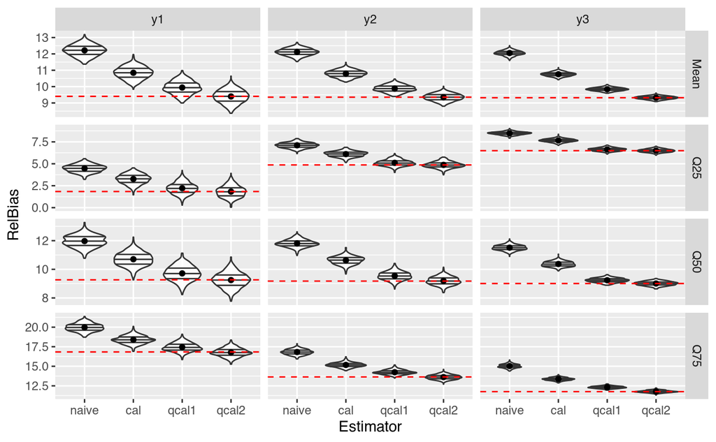

```r
results <- rbind(results_y1, results_y2, results_y3) |> as.data.frame() |> setDT()
setnames(results, names(results),
         c("iter", "m_naive", "m_cal", "m_qcal1", "m_qcal2",
           paste(paste0("q", rep(c(25, 50, 75), times = 4)), rep(c("naive", "cal", "qcal1", "qcal2"), each = 3), sep="_")))
results[, y:=rep(c("y1", "y2", "y3"), each = n_reps)]
results <- melt(results, id.vars = c("iter", "y"), value.name = "value", variable.name = "estimator")
results[, c("estimator", "type") := tstrsplit(estimator, "_")]
results <- results[pop_true_vals, on = c("y", "estimator")]
results[, type:= factor(type, c("naive", "cal", "qcal1", "qcal2"))]
results[, estimator:= factor(estimator, c("m", "q25", "q50", "q75"), c("Mean", "Q25", "Q50", "Q75"))]
pop_true_vals[, estimator2:= factor(estimator, c("m", "q25", "q50", "q75"), c("Mean", "Q25", "Q50", "Q75"))]

results |>
  ggplot(data = _, aes(x = type, y = value)) +
  #geom_jitter(alpha = 0.05, shape = 1) +
  geom_violin(alpha = 0.8, draw_quantiles = c(0.25, 0.5, 0.75)) +
  stat_summary(fun = mean, geom = "point") +
  facet_grid(estimator ~ y, scales = "free_y")  +
  geom_hline(data = pop_true_vals[, .(y, estimator=estimator2, true)],
             aes(yintercept = true), linetype = "dashed", color = "red") +
  labs(x = "Estimator", y = "RelBias")
```

```r
results[, .(mean = mean(value), bias=mean(value)-mean(true), var = var(value)), .(y, estimator, type)][
  , ":="(mse = bias^2+var, rmse = sqrt(bias^2+var))][order(y, estimator)]
```

| y | estimator | type | mean | bias | var | mse | rmse |
| --- | --- | --- | --- | --- | --- | --- | --- |
| y1 | Mean | naive | 12.214463 | 2.810149834 | 0.116286240 | 8.01322833 | 2.83076462 |
| y1 | Mean | cal | 10.844699 | 1.440386251 | 0.135008497 | 2.20972105 | 1.48651305 |
| y1 | Mean | qcal1 | 9.941612 | 0.537299244 | 0.151945070 | 0.44063555 | 0.66380385 |
| y1 | Mean | qcal2 | 9.398396 | -0.005917140 | 0.161239100 | 0.16127411 | 0.40158948 |
| y1 | Q25 | naive | 4.474285 | 2.637608993 | 0.193701174 | 7.15068237 | 2.67407598 |
| y1 | Q25 | cal | 3.265407 | 1.428731300 | 0.307236542 | 2.34850967 | 1.53248480 |
| y1 | Q25 | qcal1 | 2.211147 | 0.374471143 | 0.408668300 | 0.54889694 | 0.74087579 |
| y1 | Q25 | qcal2 | 1.830764 | -0.005911815 | 0.413478966 | 0.41351392 | 0.64305048 |
| y1 | Q50 | naive | 11.971246 | 2.704310066 | 0.177060014 | 7.49035295 | 2.73685092 |
| y1 | Q50 | cal | 10.705822 | 1.438885199 | 0.223413481 | 2.29380410 | 1.51453098 |

[output cut: 38 more lines]

## Estimated population totals and quantiles

```r
n_reps <- 500
results_y3_sample <- results_y2_sample <- results_y1_sample <- matrix(data=0, nrow = n_reps, ncol = (1+length(p_quantiles))*4+1)
```

```r
for (r in 1:n_reps) {
  set.seed(r)
  sample_nonprob <- pop_data[which(sampling::UPpoisson(pop_data$pA_1)==1),]
  sample_nonprob$w_naive <- N/n_1
  sample_prob <- pop_data[syspps(pop_data$pB_1, n_1), ] ## bottleneck
  sample_prob_svy <- svydesign(ids=~1, probs =~pB_1, data = sample_prob)

  q_est <- svyquantile( ~ x2 + x3 + x4, sample_prob_svy, p_quantiles)
  x_totals <- svytotal( ~ x1 + x2 + x3 + x4, sample_prob_svy) |> as.numeric()
  N_hat <- sum(weights(sample_prob_svy))

  w_res <- calib_quantiles(X_q = with(sample_nonprob, cbind(x2, x3, x4)),
                            d = sample_nonprob$w_naive,
                            N=N_hat,
                            totals_q = list(q_est$x2[, 1], q_est$x3[, 1], q_est$x4[, 1]),
                            method = "raking",
                            backend = "sampling")


  w_res2 <- calib_quantiles(X_q = with(sample_nonprob, cbind(x2, x3, x4)),
                           X =  with(sample_nonprob, cbind(x1, x2, x3, x4)),
                           d = sample_nonprob$w_naive,
                           N=N_hat,
                           totals = x_totals,
                           totals_q = list(q_est$x2[, 1], q_est$x3[, 1], q_est$x4[, 1]),
                           method = "raking",
                           backend = "sampling")

  w_res_st <- calib(Xs = with(sample_nonprob, cbind(x1, x2, x3, x4)),
                    d = sample_nonprob$w_naive,
                    total = x_totals,
                    method = "raking")

  sample_nonprob$w_cal_q1 <- w_res$w
  sample_nonprob$w_cal_q2 <- w_res2$w
  sample_nonprob$w_cal_s <- sample_nonprob$w_naive*w_res_st

  results_y1_sample[r, 1] <- r
  results_y1_sample[r, 2] <- with(sample_nonprob, mean(y1))
  results_y1_sample[r, 3] <- with(sample_nonprob, weighted.mean(y1, w_cal_s))
  results_y1_sample[r, 4] <- with(sample_nonprob, weighted.mean(y1, w_cal_q1))
  results_y1_sample[r, 5] <- with(sample_nonprob, weighted.mean(y1, w_cal_q2))
  results_y1_sample[r, 6:8] <- with(sample_nonprob, quantile(y1, p_quantiles))
  results_y1_sample[r, 9:11] <- with(sample_nonprob, weightedQuantile(y1, w_cal_s, p_quantiles))
  results_y1_sample[r, 12:14] <- with(sample_nonprob, weightedQuantile(y1, w_cal_q1, p_quantiles))
  results_y1_sample[r, 15:17] <- with(sample_nonprob, weightedQuantile(y1, w_cal_q2, p_quantiles))

  results_y2_sample[r, 1] <- r
  results_y2_sample[r, 2] <- with(sample_nonprob, mean(y2))
  results_y2_sample[r, 3] <- with(sample_nonprob, weighted.mean(y2, w_cal_s))
  results_y2_sample[r, 4] <- with(sample_nonprob, weighted.mean(y2, w_cal_q1))
  results_y2_sample[r, 5] <- with(sample_nonprob, weighted.mean(y2, w_cal_q2))
  results_y2_sample[r, 6:8] <- with(sample_nonprob, quantile(y2, p_quantiles))
  results_y2_sample[r, 9:11] <- with(sample_nonprob, weightedQuantile(y2, w_cal_s, p_quantiles))
  results_y2_sample[r, 12:14] <- with(sample_nonprob, weightedQuantile(y2, w_cal_q1, p_quantiles))
  results_y2_sample[r, 15:17] <- with(sample_nonprob, weightedQuantile(y2, w_cal_q2, p_quantiles))

  results_y3_sample[r, 1] <- r
  results_y3_sample[r, 2] <- with(sample_nonprob, mean(y3))
  results_y3_sample[r, 3] <- with(sample_nonprob, weighted.mean(y3, w_cal_s))
  results_y3_sample[r, 4] <- with(sample_nonprob, weighted.mean(y3, w_cal_q1))
  results_y3_sample[r, 5] <- with(sample_nonprob, weighted.mean(y3, w_cal_q2))
  results_y3_sample[r, 6:8] <- with(sample_nonprob, quantile(y3, p_quantiles))
  results_y3_sample[r, 9:11] <- with(sample_nonprob, weightedQuantile(y3, w_cal_s, p_quantiles))
  results_y3_sample[r, 12:14] <- with(sample_nonprob, weightedQuantile(y3, w_cal_q1, p_quantiles))
  results_y3_sample[r, 15:17] <- with(sample_nonprob, weightedQuantile(y3, w_cal_q2, p_quantiles))

}
```

Combine results

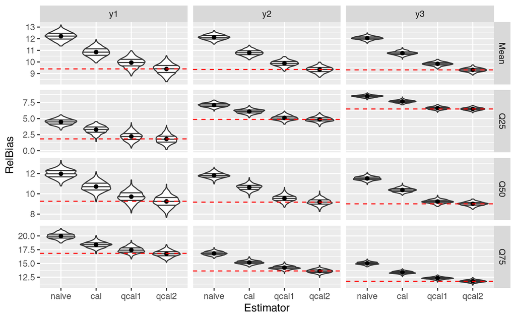

```r
results_sample <- rbind(results_y1_sample, results_y2_sample, results_y3_sample) |> as.data.frame() |> setDT()
setnames(results_sample, names(results_sample),
         c("iter", "m_naive", "m_cal", "m_qcal1", "m_qcal2",
           paste(paste0("q", rep(c(25, 50, 75), times = 4)), rep(c("naive", "cal", "qcal1", "qcal2"), each = 3), sep="_")))
results_sample[, y:=rep(c("y1", "y2", "y3"), each = n_reps)]
results_sample <- melt(results_sample, id.vars = c("iter", "y"), value.name = "value", variable.name = "estimator")
results_sample[, c("estimator", "type") := tstrsplit(estimator, "_")]
results_sample <- results_sample[pop_true_vals, on = c("y", "estimator")]
results_sample[, type:= factor(type, c("naive", "cal", "qcal1", "qcal2"))]
results_sample[, estimator:= factor(estimator, c("m", "q25", "q50", "q75"), c("Mean", "Q25", "Q50", "Q75"))]

results_sample |>
  ggplot(data = _, aes(x = type, y = value)) +
  #geom_jitter(alpha = 0.05, shape = 1) +
  geom_violin(alpha = 0.8, draw_quantiles = c(0.25, 0.5, 0.75)) +
  stat_summary(fun = mean, geom = "point") +
  facet_grid(estimator ~ y, scales = "free_y")  +
    geom_hline(data = pop_true_vals[, .(y, estimator=estimator2, true)],
             aes(yintercept = true), linetype = "dashed", color = "red") +
  labs(x = "Estimator", y = "RelBias")
```

```r
results_sample[, .(mean = mean(value), bias=mean(value)-mean(true), var = var(value)), .(y, estimator, type)][
  , ":="(mse = bias^2+var, rmse = sqrt(bias^2+var))][order(y, estimator)]
```

| y | estimator | type | mean | bias | var | mse | rmse |
| --- | --- | --- | --- | --- | --- | --- | --- |
| y1 | Mean | naive | 12.214463 | 2.810149834 | 0.11628624 | 8.01322833 | 2.8307646 |
| y1 | Mean | cal | 10.848832 | 1.444519049 | 0.14586373 | 2.23249902 | 1.4941550 |
| y1 | Mean | qcal1 | 9.941012 | 0.536698565 | 0.16798078 | 0.45602613 | 0.6752971 |
| y1 | Mean | qcal2 | 9.396309 | -0.008004213 | 0.18091285 | 0.18097692 | 0.4254138 |
| y1 | Q25 | naive | 4.474285 | 2.637608993 | 0.19370117 | 7.15068237 | 2.6740760 |
| y1 | Q25 | cal | 3.277406 | 1.440730740 | 0.31706725 | 2.39277232 | 1.5468589 |
| y1 | Q25 | qcal1 | 2.215353 | 0.378676955 | 0.43572992 | 0.57912616 | 0.7610034 |
| y1 | Q25 | qcal2 | 1.824974 | -0.011701235 | 0.43381699 | 0.43395391 | 0.6587518 |
| y1 | Q50 | naive | 11.971246 | 2.704310066 | 0.17706001 | 7.49035295 | 2.7368509 |
| y1 | Q50 | cal | 10.711020 | 1.444083765 | 0.22641770 | 2.31179562 | 1.5204590 |

[output cut: 38 more lines]